# Chapter 2 Regression and model validation

(5.11.-11.11.2019)

- **Work through the DataCamp**

  DataCamp 3 Regression and model validation
- **Data wrangling**

  R script of data Wrangling exercise is available here.

  https://github.com/yufanyin/IODS-project/blob/master/create_learning2014.R

  The result was saved as ‘learning2014.csv’.

**Note:** ‘(Step N)’ is used for reviewers to check my work queicky.

## 2.1 Reading the data

Read the data file (Step 1a)

```r
learning2014 <-
read.table(file = "G:/C-Open Data Science/0-191030/IODS-project-master/learning2014.txt", stringsAsFactors = TRUE)
str(learning2014)
```

```
## 'data.frame':    166 obs. of  7 variables:
##  $ gender  : Factor w/ 2 levels "F","M": 1 2 1 2 2 1 2 1 2 1 ...
##  $ age     : int  53 55 49 53 49 38 50 37 37 42 ...
##  $ attitude: num  3.7 3.1 2.5 3.5 3.7 3.8 3.5 2.9 3.8 2.1 ...
##  $ deep    : num  3.58 2.92 3.5 3.5 3.67 ...
##  $ stra    : num  3.38 2.75 3.62 3.12 3.62 ...
##  $ surf    : num  2.58 3.17 2.25 2.25 2.83 ...
##  $ points  : int  25 12 24 10 22 21 21 31 24 26 ...
```

Describe the dataset briefly (Step 1b)

The data ‘learning2014’ consists of 166 observations and 7 variables. It contains students’ approaches to learning (deep, stra, surf), scores of attitude, points and some background information (gender, age).

## 2.2 Visualizations with ggplot2

(Step 2)

Correlations of the observations between the different variables are shown below with `ggpairs()` function.

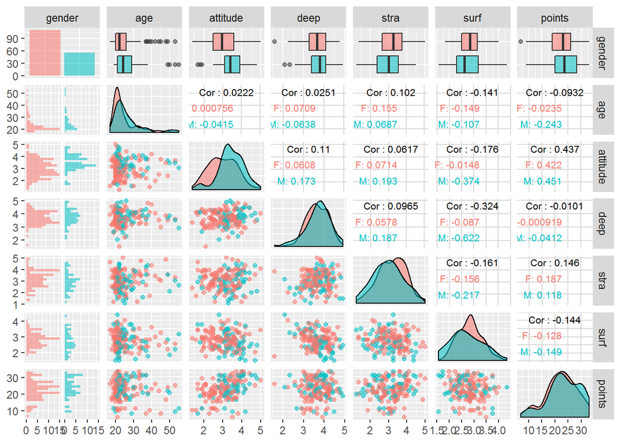

```r
library(ggplot2)
library(GGally)
p1 <- ggpairs(learning2014, mapping = aes(col = gender, alpha = 0.3), lower = list(combo = wrap("facethist", bins = 20)), upper = list(continuous = wrap("cor", size = 2.8)))
p1
```

The plot shows the data distribution of all the 166 observations of each variable. The colours represent different gender. Female students are shown in red and male students in verdant. In the upper right part presents how one variable correlates to another varibable. We are able to find possible significant regression result.

## 2.3 Simple regression with lm()

(Step 3)

**Simple regression: point ~ gender** Firstly we choose gender as explanatory variables and fit a regression model in which exam points is the dependent variable. Result: not significant.

```r
gender_lm <- lm(points ~ gender, data = learning2014)
summary(gender_lm)
```

```
##
## Call:
## lm(formula = points ~ gender, data = learning2014)
##
## Residuals:
##      Min       1Q   Median       3Q      Max
## -15.3273  -3.3273   0.5179   4.5179  10.6727
##
## Coefficients:
##             Estimate Std. Error t value Pr(>|t|)
## (Intercept)  22.3273     0.5613  39.776   <2e-16 ***
## genderM       1.1549     0.9664   1.195    0.234
## ---
## Signif. codes:  0 '***' 0.001 '**' 0.01 '*' 0.05 '.' 0.1 ' ' 1
##
## Residual standard error: 5.887 on 164 degrees of freedom
## Multiple R-squared:  0.008632,   Adjusted R-squared:  0.002587
## F-statistic: 1.428 on 1 and 164 DF,  p-value: 0.2338
```

**Simple regression: point ~ attitude**

```r
gender_lm <- lm(points ~ attitude, data = learning2014)
summary(gender_lm)
```

```
##
## Call:
## lm(formula = points ~ attitude, data = learning2014)
##
## Residuals:
##      Min       1Q   Median       3Q      Max
## -16.9763  -3.2119   0.4339   4.1534  10.6645
##
## Coefficients:
##             Estimate Std. Error t value Pr(>|t|)
## (Intercept)  11.6372     1.8303   6.358 1.95e-09 ***
## attitude      3.5255     0.5674   6.214 4.12e-09 ***
## ---
## Signif. codes:  0 '***' 0.001 '**' 0.01 '*' 0.05 '.' 0.1 ' ' 1
##
## Residual standard error: 5.32 on 164 degrees of freedom
## Multiple R-squared:  0.1906, Adjusted R-squared:  0.1856
## F-statistic: 38.61 on 1 and 164 DF,  p-value: 4.119e-09
```

There is a statistical relationship between point and attitude (p:4.12e-09). Then draw a scatter plot of points versus attitude, fit a linear model and print out the summary.

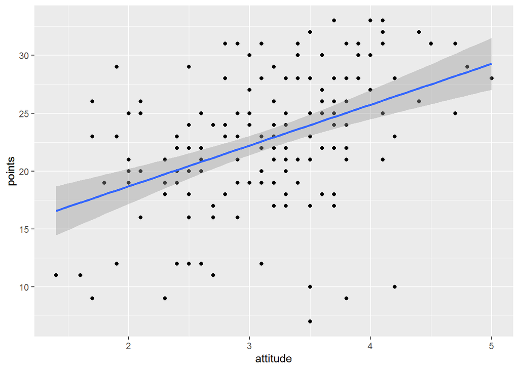

```r
qplot(attitude, points, data = learning2014) + geom_smooth(method = "lm")
```

```r
model_point_attitude <- lm(points ~ attitude, data = learning2014)
model_point_attitude
```

```
##
## Call:
## lm(formula = points ~ attitude, data = learning2014)
##
## Coefficients:
## (Intercept)     attitude
##      11.637        3.525
```

## 2.4 Multiple regression

(Step 4)

**Multiple regression model: point ~ attitude + stra** This multiple regression is to test whether strategic learning has an influence on points. The p-value (0.08) shows that the significance of the influence is not very strong. The multiple R-squared is a bit higher than that in regression model of points ~ attitude. That means a little higher correlations if strategic learning is taken into account.

```r
model_p_att_stra <- lm(points ~ attitude + stra, data = learning2014)
model_p_att_stra_s <- summary(model_p_att_stra)
model_p_att_stra_s
```

```
##
## Call:
## lm(formula = points ~ attitude + stra, data = learning2014)
##
## Residuals:
##      Min       1Q   Median       3Q      Max
## -17.6436  -3.3113   0.5575   3.7928  10.9295
##
## Coefficients:
##             Estimate Std. Error t value Pr(>|t|)
## (Intercept)   8.9729     2.3959   3.745  0.00025 ***
## attitude      3.4658     0.5652   6.132 6.31e-09 ***
## stra          0.9137     0.5345   1.709  0.08927 .
## ---
## Signif. codes:  0 '***' 0.001 '**' 0.01 '*' 0.05 '.' 0.1 ' ' 1
##
## Residual standard error: 5.289 on 163 degrees of freedom
## Multiple R-squared:  0.2048, Adjusted R-squared:  0.1951
## F-statistic: 20.99 on 2 and 163 DF,  p-value: 7.734e-09
```

## 2.5 Diagnostic plots

(Step 5)

The results of diagnostic plots are in accordance with the regression model.

The residuals is close to the 0 line, which means that the relationship is linear. Not many outliers (35, 56,145) are significantly disturbing the analysis but they raise errors in the dataset.

According to Nomal Q-Q plot, most of the values fall on the straight line. The outliers cause randomness in the dataset.

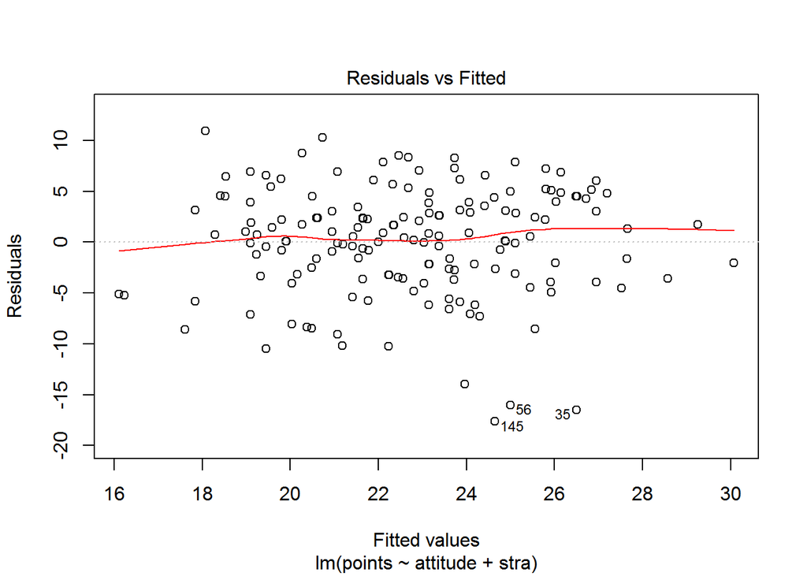

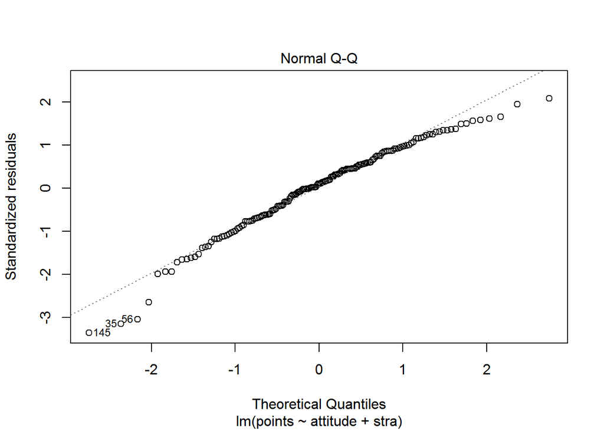

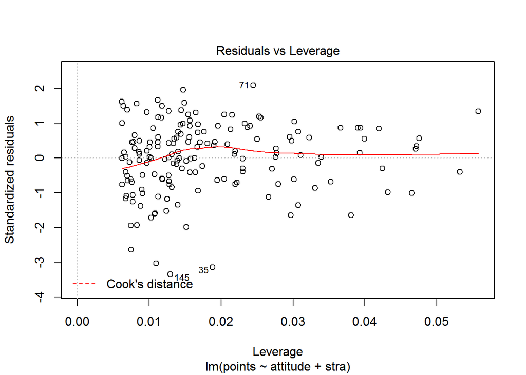

```r
plot(model_p_att_stra, which=c(1,2,5))
```